# Bioinformatics tutorial: eDNA metabarcoding

Dr. Gert-Jan Jeunen

July, 2021

## 1. Introduction

### *1.1. About this document*

Welcome to this tutorial on analysing eDNA metabarcoding data!

The purpose of this document is to give an introduction to the bioinformatics of eDNA metabarcoding and make you comfortable to explore your own next generation sequencing data. Over the course of this document, we’ll introduce the concept of metabarcoding and go through the different steps of a bioinformatic pipeline, from raw sequencing data to an OTU table with taxonomic assignments. At the end of this tutorial, you will be able to assemble paired-end sequences, demultiplex fastq sequencing files, filter sequences based on quality, cluster and denoise sequence data, and assign taxonomy to OTUs. Together with this document, you will be provided with an example raw sequencing data file and a metadata file that will allow you to follow along with the example code provided in this tutorial.

If you do not have access to the example sequencing data or metadata file, please contact me at gjeunen@gmail.com. Before starting, check if you have the most recent version of this tutorial. Please do not distribute this document without written consent from the author.

### *1.2. Introduction to library preparation*

As of the time of writing this tutorial, PCR amplification is the main method to generate eDNA metabarcoding libraries. To achieve species detection from environmental or bulk specimen samples, PCR amplification is carried out with primers designed to target a taxonomically informative marker within a taxonomic group. Furthermore, next generation sequencing data generates millions of sequences in a single sequencing run. Therefore, multiple samples can be combined. To achieve this, a unique sequence combination is added to the amplicons of each sample. This unique sequence combination is usually between 6 and 8 base pairs long and is referred to as ‘tag’, ‘index’, or ‘barcode’. Besides amplifying the DNA and adding the unique barcodes, sequencing primers and adapters need to be incorporated into the library to allow the DNA to be sequenced by the sequencing machine.

Currently, there are three main methods used to prepare metabarcoding libraries, i.e., ligation, two-step PCR, and single-step PCR. While each of these methods have their advantages and downsides, the main difference of importance to this tutorial is in the construction of the sequences and the sequencing data files you will receive from the sequencing service. For a more in depth discussion on this topic, you can have a look at this paper: https://d197for5662m48.cloudfront.net/documents/publicationstatus/63307/preprint_pdf/bc94606c8c77c5030fea3f93a95c21b0.pdf.

Traditionally prepared Illumina libraries (ligation and two-step PCR) are constructed in the following manner (the colours mentioned refer to the figure below):

1. Forward Illumina adapter (red)
2. Forward barcode sequence (darkgreen)
3. Forward Illumina sequencing primer (orange)
4. Amplicon (including primers)
5. Reverse Illumina sequencing primer (lightblue)
6. Reverse barcode sequence (lightgreen)
7. Reverse Illumina adapter (darkblue)

This construction allows the Illumina software to identify the barcode sequences, which will result in the generation of a separate sequence file (or two for paired-end sequencing data) for each sample. This process is referred to as *demultiplexing* and is performed by the Illumina software.

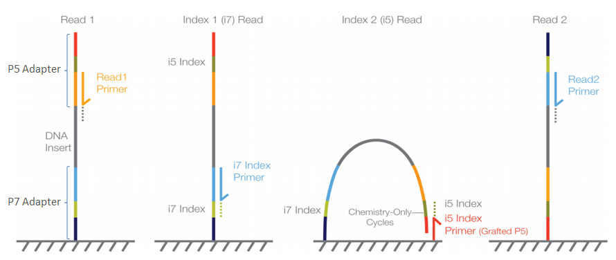

When libraries are prepared using the single-step PCR method, the libraries are constructed slightly different (the colours mentioned refer to the setup described in the two-step approach):

1. Forward Illumina adapter (red)
2. Forward Illumina sequencing primer (orange)
3. Forward barcode sequence (darkgreen)
4. Amplicon (including primers)
5. Reverse barcode sequence (lightgreen)
6. Reverse Illumina sequencing primer (lightblue)
7. Reverse Illumina adapter (darkblue)

In this construction, the barcode sequences are not located in between the Illumina adapter and Illumina sequencing primer, but are said to be ‘inline’. These inline barcode sequences cannot be identified by the Illumina software, since it does not know when the barcode ends and the primer sequence of the amplicon starts. Therefore, this will result in a single sequence file (or two for paired-end sequencing data) containing the data for all samples together. The *demultiplexing* step, assigning sequences to a sample, will have to be incorporated into the bioinformatic pipeline.

For more information on Illumina sequencing, you can watch the following 5-minute youtube video (https://www.youtube.com/watch?v=fCd6B5HRaZ8). Notice that the ‘Sample Prep’ method described in the video follows the two-step PCR approach.

The tutorial dataset is prepared using the single-step PCR approach and the demultiplexing step is described in section **5. Demultiplexing**. If your own data is generated using a different approach, you can still follow the tutorial by omitting section 5.

### *1.3. Software used in this tutorial*

Since the start of eDNA metabarcoding research, lab groups have been using several pre-existing software programs and even developed new ones to analyse metabarcoding sequence data. Furthermore, frequent updates are made to each software and newly developed programs are made available on a regular basis. This means that there are multiple ways to analyse your data, without there being a clear optimal or standardised way.

Although software options are numerous, each pipeline follows the same basic steps, i.e., assembling paired reads (only for paired-end sequencing; excluded in single-end sequencing), demultiplexing the data, quality filtering, denoising or clustering, and taxonomic assignment. More information on each of these steps can be found in the corresponding sections in this document.

Modifications to or rearanging these steps can be done to optimise the pipeline for your specific data. Some software programs are equipped to handle all of these steps, such as QIIME (website: https://qiime2.org) or ObiTools3 (website: https://git.metabarcoding.org/obitools/obitools3). Other software programs are optimised for a single or subset of steps, such as cutadapt (website: https://cutadapt.readthedocs.io/en/stable/) or PEAR (website: https://cme.h-its.org/exelixis/web/software/pear/doc.html). Although it might seem easier to use a program that can be used to run through the pipeline in one go, this usually leads to a ‘black box’ situation and can be limiting if other software programs might have additional options. It is, therefore, recommended to understand each step in the bioinformatic pipeline and how different software programs implement these steps.

One issue you will run into when implementing several software programs in your bioinformatic pipeline is that each program might change the structure of the files in a specific manner. These modifications might lead to incompatability issues when switching to the next program. It is, therefore, important to understand how a specific program changes the structure of the sequencing file and learn how these modifications can be reverted back. More information on the structure of fastq and fasta sequencing file formats is provided in section *4.4. Checking files with text editors*.

In this tutorial, we will be using a published pipeline that incorporates multiple software programs:

- *quality control*: FastQC - https://www.bioinformatics.babraham.ac.uk/projects/fastqc/
- *assembling paired reads*: vsearch - https://pubmed.ncbi.nlm.nih.gov/27781170/
- *demultiplexing*: cutadapt - https://cutadapt.readthedocs.io/en/stable/
- *quality filtering*: vsearch - https://pubmed.ncbi.nlm.nih.gov/27781170/
- *denoising and clustering*: vsearch - https://pubmed.ncbi.nlm.nih.gov/27781170/
- *taxonomic assignment eukaryotes*: sintax or BLAST - https://www.drive5.com/usearch/manual/sintax_algo.html; https://blast.ncbi.nlm.nih.gov/
- *taxonomic assignment bacteria*: sintax - https://www.drive5.com/usearch/manual/sintax_algo.html

### *1.4. How to use this document*

This document is made as a guide to help students in the Gemmell lab (website: https://gemmell-lab.otago.ac.nz). However, this document can also be used as a standalone guide for anyone interested in learning how to analyse metabarcoding data. This document provides additional information about all the steps in the bioinformatic pipeline, sample code, information about each command, and sample output. For students in the Gemmell lab, it is recommended to use this document as a guide to practise analysing your data. Afterwards, you are encouraged to deviate from this pipeline, explore other options and optimise the analysis for your own data.

Each section in this document is dedicated to a specific step in the bioinformatic pipeline. The sections will start by introducing the concept. Afterwards, sample code is given, which looks like this:

```
example code
```

This sample code will use the file names associated with the example data provided with this tutorial where applicable. In other instances (*4.3. Merging paired-end sequences*; *8.2. Assigning taxonomy for Bacteria*) the code provided uses ‘standard’ filenames. The sample code is followed by an explanation of every option of the command and a figure of the output file whenever possible.

If you encounter an error message when following this tutorial, please check if you (1) are using the correct filenames, (2) are in the correct folder in the terminal, and (3) made any typo’s. These are the most common reasons you will see error messages.

**Let’s get started!**

## 2. Setting up the folder structure

Before we start processing the data, it is a good idea to set up a standard folder structure where you will place your sequencing file and downstream generated files. Once you have placed your sequencing fastq files and metadata file in a specific folder, open up *Terminal* and move to this folder using the ‘cd’ command. For example, I placed the tutorial sequencing and metadata file in a folder named ‘tutorial_eDNA_metabarcoding’ on my Desktop.

```
cd Desktop/tutorial_eDNA_metabarcoding
```

We can now list all the files (our sequencing and metadata files) in this folder to make sure that we are in the correct place in the terminal.

```
ls -ltr
```

The output of this command should show you the sequencing and metadata files, as in the figure below. If this is not the case, you need to navigate to the correct folder using your terminal before proceeding.

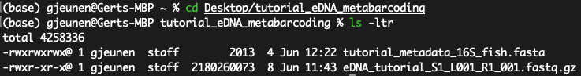

Within this folder, we will create subfolders using the ‘mkdir’ command to organise the files generated during our bioinformatic processing.

```
mkdir input output filter final scripts meta raw
```

Next, we will copy our sequencing files to the raw and input folder and the metadata in the meta folder. The reason we are copying the sequencing file to the raw folder, is to have a backup of the data in case something went wrong during the analysis. If this would be the case, you can copy a new version into the input folder from the raw folder. **Never use the sequencing file in the raw folder for your bioinformatic analysis!** The sequencing file for this tutorial is called ‘eDNA_tutorial_S1_L001_R1_001.fastq.gz’ and represents a single-end sequencing run on the Illumina MiSeq platform using the 1x300 bp chemistry kit. The metadata file is called ‘tutorial_metadata_16S_fish.fasta’ and contains the information needed for demultplexing the sequencing file. More information on this is provided in section **5. Demultiplexing**.

```
cp eDNA_tutorial_S1_L001_R1_001.fast.gz raw
```

```
mv eDNA_tutorial_S1_L001_R1_001.fast.gz input
```

```
mv tutorial_metadata_16S_fish.fasta meta
```

Lastly, we will check if the folder structure was set up properly and if the files were moved in the correct subfolders. You can do this by navigating to the folder with your mouse or by using the terminal with the following commands:

```
ls -ltr
```

```
ls -ltr raw
```

```
ls -ltr input
```

```
ls -ltr meta
```

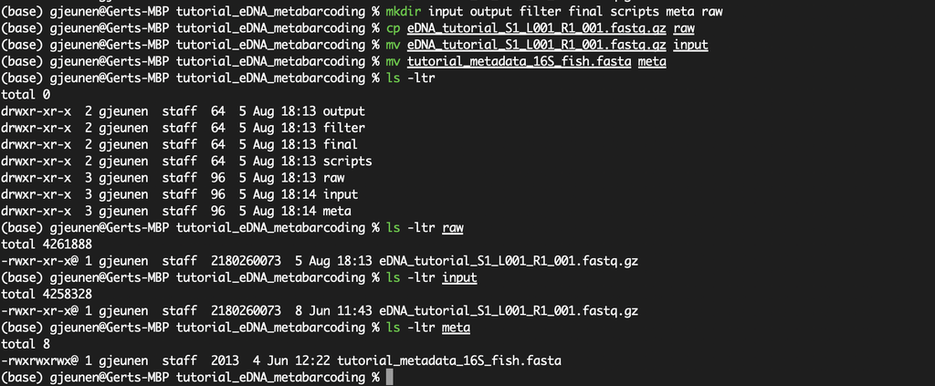

## 3. Using scripts to execute code

In this tutorial, we generate scripts that contain the code used to process the sequencing data. Although it is possible to run the commands without using scripts, it is good practice to use this method for the following three reasons:

1. By using scripts to execute the code, there is a written record of how the data was processed. This will make it easier to remember how the data was processed in the future.
2. While the sample data provided in this tutorial is small and computing steps take up a maximum of several minutes, processing large data sets can be time consuming. It is, therefore, recommended to process a small portion of the data first to test the code, modify the filenames once everything is set up, and run it on the full data set.
3. Scripts can be reused in the future by changing file names, saving you time by not having to constantly write every line of code in the terminal. Minimising the amount needing to be written in the terminal will, also, minimise the risk of receiving error messages due to typo’s.

## 4. Assembling paired reads

### *4.1. Introduction*

**note 1:** When using the supplied sequencing file for the tutorial, you can skip step *4.3. Merging paired-end sequences*, since the data provided is single-end.

**note 2:** skip step *4.3. Merging paired-end sequences* if you have single-end sequencing data.

Once the sequencing run is completed, one or two files will be provided to you depending on the sequencing options that were chosen. The file names might appear random, but will always end in **R1_001.fastq.gz** and **R2_001.fastq.gz**, for the forward and reverse sequencing file, respectively. If the library was sequenced single-end, as is this case for the tutorial sequencing data, only the **R1_001.fastq.gz** file will be provided. Sequencing files might be zipped (**.gz**) to reduce the file size. Most software will be able to read and use zipped files, so there is no need to unzip them now. However, always check if this is the case when using new software.

### *4.2. Quality control*

The first thing we will do with our sequencing file is to look at the quality and make sure everything is according to the sequencing parameters that were chosen. The program we will be using for this is **FastQC** (website: https://www.bioinformatics.babraham.ac.uk/projects/fastqc/). This software has a graphical user interface (GUI) and will report on basic statistics, sequence quality, sequence length, etc. It is also possible to use the command line, which will output a .html report with the same statistics. If your library was sequenced at Otago Genomics, a .html report will have been provided along with the sequencing files. An example figure of the tutorial data can be found below.

[figure not shown]

At this stage, we will be looking at the tabs ‘Basic Statistics’ and ‘Per base sequence quality’. From this report, we can see that:

1. We have a total of 8,994,798 sequences.
2. The sequence length is 300 bp, identical to the cycle number of the sequencing kit.
3. At the end of the sequences, the quality is dropping below the indicated green area, typical for Illumina sequencing data.

### *4.3. Merging paired-end sequences*

**note 3:** This step is only needed if you have paired-end sequencing data and can be omitted when using the tutorial dataset.

Once the quality of the raw sequencing data is checked with **FastQC**, we can merge the forward (**R1_001.fastq.gz**) and reverse (**R2_001.fastq.gz**) sequencing files. During this process, we will stitch together every forward and reverse sequence to obtain a sequence of similar length to the amplicon insert size. There are a myriad of software programs that are able to merge paired-end sequences, e.g., COPE, FLASH, PANDAseq, QIIME2, PEAR, ObiTools, …

Today, we will be using **vsearch** (website: https://pubmed.ncbi.nlm.nih.gov/27781170/). When the amplicon size of your library is smaller than the cycle number of your sequencing kit, the forward and reverse sequences will partially overlap. This is highly recommended for eDNA metabarcoding and will allow you to use the basic arguments of **vsearch**.

**It is time to write our first bioinformatic script!**

```
nano scripts/merge
```

This command will open the file ‘merge’ in the nano text editor in your terminal. In here, we can type the following commands:

[output not shown]

We can exit out of the text editor by pressing ‘ctr+x’, then type ‘y’ to save the file and press ‘enter’ to save the file as ‘merge’. Next we need to make the script executable and run the script to merge the sequences.

```
chmod +x scripts/merge
```

```
./scripts/merge
```

When executed, this script will produce several files in the input directory. There will be a ‘fastq.gz’ file for the merged sequences called ‘example_merged.fastq.gz’ and two additional files for sequences that could not be merged, one for the forward (‘example_notmerged_fwd.fastq.gz’) and reverse (‘example_notmerged_rev.fastq.gz’) sequence file.

### *4.4. Checking files with text editors*

It is a good habit to occasionally check your sequencing files to see how the software changed the structure of the file and if the command did what it was supposed to do. Both sequencing files (fastq and fasta) are text files that are structured in a specific manner. Sequencing files can be read by any text editor, such as **Sublime Text**. You can also use **nano** as the text editor in your terminal.

As a first option, we can have a look at the sequencing file using the *head* command. First, we need to unzip the sequencing file.

```
gunzip input/eDNA_tutorial_S1_L001_R1_001.fastq.gz
```

```
head -10 input/eDNA_tutorial_S1_L001_R1_001.fastq
```

An example figure of the output of the *head* command can be found below. From this output, we can determine the structure of a fastq file. Every sequence comprises 4 lines, with:

- Line 1: sequence name
- Line 2: sequence
- Line 3: +
- Line 4: quality score

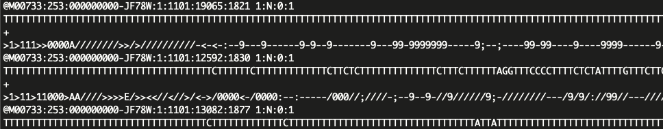

To have a look at the structure of a fasta file, we can use the *head* command on the metadata file.

**note 4:** In a normal sequencing file, the ‘^’ and ‘…’ in the sequence will not be present. This is specific to the metadata file.

```
head -10 meta/tutorial_metadata_16S_fish
```

An example figure of the output of the *head* command can be found below. The structure of fasta files are the following:

- Line 1: sequence name
- Line 2: sequence

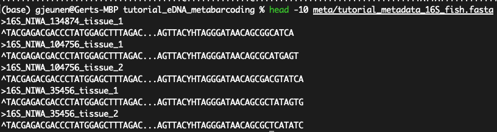

It is important to check the structure of your files, as some software programs will deviate from this standard structure. When changing from one software program to another in a bioinformatic pipeline, we need to keep in mind the modifications made by these software programs and revert the sequence files back to the original structure before continuing with the analysis if needed. If we forget to revert the structure, the data might not be read properly by the software and error messages will be prompted in the terminal.

## 5. Demultiplexing

### *5.1. Introduction*

Now that the paired-end sequences are stitched together, we will assign each sequence to the corresponding sample, a process referred to as demultiplexing.

During library preparation, each sample was assigned a specific barcode combination, with at least 3 basepair differences between each barcode used in the library. By searching for these specific sequences, which are situated at the very beginning and very end of each sequence, we can assign each sequence to the corresponding sample. We will be using **cutadapt** for demultiplexing our dataset today, as it is the fastest option. Cutadapt requires an additional text file in fasta format. This text file contains information about the sample name and the associated barcode and primer sequences. The sample name is preceded by “>”, according to the fasta file format. The forward barcode sequence is preceded by “^” to denote it should be found at the start. The forward primer sequence and reverse complemented reverse primer sequence are separated by “…”. The sequence ends with the reverse complement of the reverse barcode. A screenshot of the metadata file can be found below.

**note 5:** when generating this metadata file, make sure to use an appropriate text editor that does not change the structure of the file. *Sublime Text* is a great option that is free!

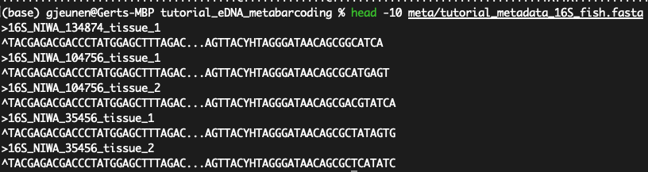

After generating the metadata text file, make sure to place the file in the ‘meta’ folder. See section **2. Setting up the folder structure**.

### *5.2. Assigning sequences to corresponding samples*

We are now ready to write our script for demultiplexing our data.

```
nano scripts/demux
```

This command will open the file ‘demux’ in the nano text editor in your terminal. In here, we can type the following commands:

```
#!/bin/bash

cd input/

cutadapt -g file:../meta/tutorial_metadata_16S_fish.fasta -o ../output/trimmed_{name}.fastq eDNA_tutorial_S1_L001_R1_001.fastq --untrimmed-output ../output/untrimmed.fastq --no-indels -e 0
```

We can exit out of the text editor by pressing ‘ctr+x’, then type ‘y’ to save the file and press ‘enter’ to save the file as ‘demux’. Next, we need to make the script executable and run the script to assign the sequences to the corresponding samples.

```
chmod +x scripts/demux
```

```
./scripts/demux
```

Once this script has been executed, it will have generated a single fastq file for each sample in the metadata file containing the amplicon sequences that were assigned to this sample. During this step, the barcodes and primer sequences have automatically been cut off and only the amplicon sequence remains.

### *5.3. Preparing sequencing files for quality filtering*

Before we can continue with quality filtration of our data, we will need to rename every sequence so that the information of the corresponding sample is incorporated. This will be needed to generate our OTU table at the end of the analysis. Lastly, we can combine all the relabeled files into a single file prior to quality filtering.

```
nano scripts/rename
```

```
#!/bin/bash

cd output/

for fq in trimmed*; do vsearch --fastq_filter $fq --relabel $fq. --fastqout relabel_$fq; done

cat relabel_trimmed* > relabel.fastq
```

```
chmod +x scripts/rename
```

```
./scripts/rename
```

When executed, this script will first rename the sequence headers of each file and store them in a new file per sample. Lastly, we have combined all relabeled files using the ‘cat’ command. You can find a figure of the sequence headers before and after renaming the files below. For this output, I used the ‘head’ command and specified an output of 4 lines, by using the ‘-n 4’ parameter. You can see in the figure that the sequence and quality score information is identical after renaming the header, but that line 1 of the sequence has changed and now incorporates the name of the sample.

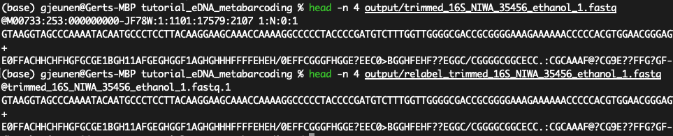

## 6. Quality filtering

### *6.1. Introduction*

During the quality filtering step, we will discard all sequences that do not adhere to a specific set of rules. We will be using the program **vsearch** (website: https://pubmed.ncbi.nlm.nih.gov/27781170/) for this step. During quality filtering, we will filter out all sequences that do not adhere to a minimum and maximum length, have unassigned base calls (‘N’), and have a higher expected error than 1. Once we have filtered our data, we can check the quality with **FastQC** and compare it to the raw sequencing file.

### *6.2. Filtering sequence data*

```
nano scripts/qual
```

```
#!/bin/bash

cd output/

vsearch --fastq_filter relabel.fastq --fastq_maxee 1.0 --fastq_maxlen 230 --fastq_minlen 150 --fastq_maxns 0 --fastaout ../filter/filtered.fasta --fastqout ../filter/filtered.fastq
```

```
chmod +x scripts/qual
```

```
./scripts/qual
```

### *6.3. Quality control*

Before we continue with the pipeline, we will check if the quality filtering was successful. We will load in the ‘filtered.fastq’ file into **FastQC**. A figure of the output can be found below.

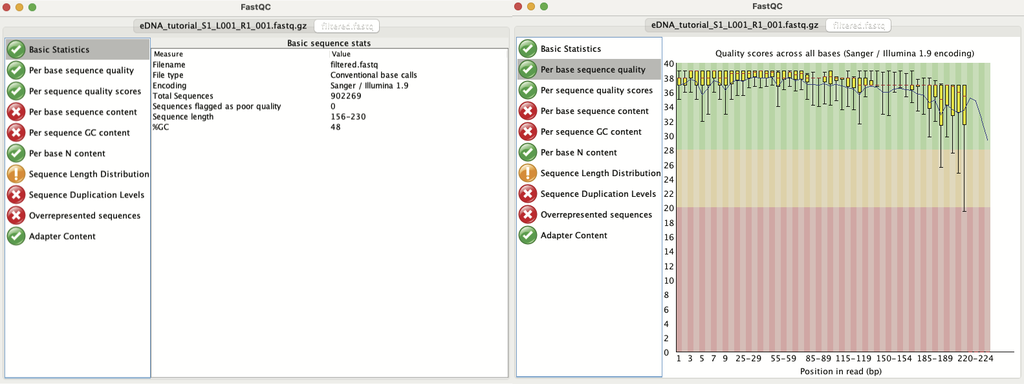

When we now look at the ‘Basic Statistics’ and ‘Per base sequence quality’ tabs, we can see that:

1. Our total number of sequences have been reduced to 902,269 sequences. (this library contained samples from multiple projects, so don’t be discouraged with the reduction of the sequences we retain after quality filtering)
2. The sequence length ranges from 156 to 230 bp, according to the amplicon length.
3. The sequence quality stays in the green zone.

We can, therefore, conclude that quality filtering was successful and move to the OTU clustering step of the pipeline.

## 7. OTU clustering

### *7.1. Introduction*

Now that the dataset is filtered and each sequence is assigned to their corresponding sample, we are ready for the next step in the bioinformatic pipeline, i.e., looking for **biologically meaningful** or **biologically correct** sequences. This is done through *denoising* or *clustering* the dataset, while at the same time removing any chimeric sequences and remaining PCR and/or sequencing errors.

There is still an ongoing debate on what the best approach is to obtain these ‘biologically meaningful’ sequences. If you would like more information, these are two good papers to start with (https://onlinelibrary.wiley.com/doi/full/10.1111/1755-0998.13398; https://bmcbioinformatics.biomedcentral.com/articles/10.1186/s12859-021-04115-6). I won’t be discussing this topic in much detail during the tutorial, but this is the basic idea…

When clustering the dataset, OTUs (Opterational Taxonomic Units) will be generated by combining sequences that are similar to a set percentage level (traditionally 97%), with the most abundant sequence identified as the true sequence. When clustering at 97%, this means that if a sequence is more than 3% different than the generated OTU, a second OTU will be generated. The concept of OTU clustering was introduced in the 1960s and has been debated since. Clustering the dataset is usually used for identifying species in metabarcoding data.

Denoising, on the other hand, attempts to identify all correct biological sequences through an algorithm, which his visualised in the figure below. In short, denoising will cluster the data with a 100% threshold and tries to identify errors based on abundance differences. The retained sequences are called ZOTU (Zero-radius Operation Taxonomic Unit) or ASVs (Amplicon Sequence Variants). Denoising the dataset is usually used for identifying intraspecific variation in metabarcoding data.

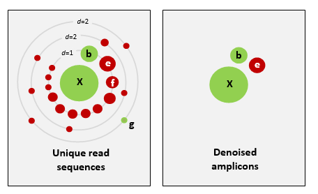

The difference in approach between *denoising* and *clustering* might seem small, but has a very big impact on your final dataset! When denoising is chosen, it is expected that one species may have more than one ZOTU, while if clustering is chosen, it might be that one OTU could be comprised of multiple closely related species. For clustering, it is possible that closely related species will not be differentiated. For denoising, on the other hand, the diversity estimate will be inflated when you cannot assign a taxonomy to each ZOTU, due to incomplete reference databases.

For this tutorial, we will cluster the data, since the samples of the tutorial data were collected in a remote area with limited reference sequences. If you opt to denoise the dataset, more information can be found in the VSEARCH manual on what code to use.

### *7.2. Clustering*

Before we can cluster our dataset, we need to dereplicate the sequences into unique sequences. Since metabarcoding data is based on an amplification method, the same DNA molecule can be sequenced several times. In order to reduce file size and computational time, it is convenient to work with unique sequences.

During dereplication, we will remove unique sequences that are not prevalent in our dataset. There is still not a standardised guide to the best cutoff. Many eDNA metabarcoding publications remove only the singleton sequences, i.e., sequences that are present once in the dataset, while others opt to remove unique sequences occurring less than three or ten times. Given there isn’t a standard approach, we will be using the more strict approach of removing sequences occurring fewer than 10 times in the dataset.

After clustering, we have to remove chimeric sequences from the generated OTUs. Chimeric sequences are generated during PCR amplification where one half of the sequence is from one DNA molecule and the other half from another DNA molecule. More information about chimeric sequences can be found on these two websites: https://www.ncbi.nlm.nih.gov/genbank/rrnachimera/; https://drive5.com/usearch/manual/chimeras.html.

Once we have the final set of OTUs, we can generate the OTU table by determining how many sequences map to each OTU for every sample. All of the abovementioned steps are included in the script below.

```
nano scripts/clust
```

```
#!/bin/bash

cd filter/

vsearch --derep_fulllength filtered.fasta --relabel uniq. -output uniques.fasta --sizeout --minuniquesize 10

vsearch --cluster_size uniques.fasta --centroids otus.fasta --relabel otu. --id 0.97 --sizeout

vsearch --uchime3_denovo otus.fasta --nonchimeras ../final/otus_chimeras_removed.fasta --chimeras chimeras.fasta

vsearch --usearch_global filtered.fasta --db ../final/otus_chimeras_removed.fasta --strand plus --otutabout ../final/otutable.txt --id 0.97
```

```
chmod +x scripts/clust
```

```
./scripts/clust
```

When executed, we have generated a list of 29 OTUs and an OTU table containing a combined total of 892,807 sequences.

## 8. Taxonomic assignment

### *8.1. Introduction*

Once we have an OTU list and an OTU table, the final step before the statistical analysis is to assign a taxonomy to each sequence. Taxonomic assignment can be done in a myriad of ways, e.g., alignment-based, probabilistic, tree-based, and phylogeny-based. Each of these methods have their upsides and drawbacks, and while we will focus on one method in this tutorial, it would be beneficial to explore other methods and determine the most optimal strategy for your sequencing data.

Alignment-based approaches utilise various measures of similarity between query and reference sequences based solely on their alignment. The most famous example of this approach is BLAST (website: https://blast.ncbi.nlm.nih.gov). Probabilistic approaches rely on likelihood estimates of OTU placement and include the UTAX algorithm of the USEARCH software and Statistical Assignment Package (SAP). The tree-based approach evaluates similarity between query and reference sequences by analysing the position of each individual OTU relative to reference sequence on the cladogram and the bootstrap support that it receives. Phylogeny-based identification of query sequences, on the other hand, is performed in three stages. During the preparation stage, a manually curated reference alignment is created using full length sequences of the gene that includes the barcoding region. A reference phylogeny is estimated based on this alignment. Taxonomic assignment of the query barcodes is then done by using the referece tree as constraint and testing placement of query reads across all nodes in the reference topology, with placement likelihood claculated for every combination.

In this tutorial, we will be using custom curated reference databases and the sintax algorithm in the VSEARCH software program (website: https://pubmed.ncbi.nlm.nih.gov/27781170/).

### *8.2. Assigning taxonomy for Bacteria*

When assigning the taxonomy for bacterial data, we will be using the RDP training set. This is a smaller and curated reference database generated from the full RDP database. The database can be downloaded from this website: https://drive5.com/usearch/manual/sintax_downloads.html. We will be downloading the file named: ‘rdp_16s_v16.fa.gz’. More information on the database and the sintax algorithm can be found in this paper: https://doi.org/10.1101/074161.

We will unzip this reference database file using the ‘gunzip’ command after placing it in the correct folder. For this tutorial, we will place the reference database in the meta folder using the ‘mv’ command.

```
mv ../../rdp_16s_v16.fa.gz meta/
```

```
gunzip rdp_16s_v16.fa.gz
```

Next, we are ready to assign the taxonomy for the OTUs.

```
nano scripts/tax
```

```
#!/bin/bash

cd final/

vsearch --sintax otus_chimeras_removed.fasta --db ../meta/rdp_16s_v16.fa --tabbedout taxonomy_OTU_sintax.txt
```

```
chmod +x scripts/tax
```

```
./scripts/tax
```

This script will create a tab delimited text file, with column 1 containing information about the query label, column 2 containing the predicted taxonomy in sintax format (more info on the format can be found in the VSEARCH manual), column 3 containing the strand info, and if a cutoff option is used (not in the example), column 4 will contain the taxonomy assignment supported by the bootstrap threshold.

This file can now be combined with the OTU table to provide a single excel spreadsheet with sample names and OTUs containing taxonomic classification. This can be easily achieved in excel, python, or R with some basic codes. From here, you can import it into your statistical analysis scripts!

#### **Thank you all for your attention!**

### *8.3. Assigning taxonomy for Eukaryotes*

When assigning the taxonomy for eukaryote data, curated reference databases are unfortunately not available. OBITools3 is a software program (website: https://git.metabarcoding.org/obitools/obitools3) that allows you to download the EMBL genetic database and run an *in silico* PCR on the database to help you build a curated reference database for your primer assay. However, this program takes up more than 1 TB of storage and it will take several days to complete. Therefore, we won’t be using it during this tutorial, but more information about this can be found on their website. I’m currently writing a separate program that achieves the same output, but will only take several hours rather than days and use up only several MB rather than TB. Once this program is completed, it will be added to the tutorial.

Until the software is complete, you can email me with information about the assay that you are using, the target gene, and taxonomic group that is amplified. Upon receiving this information, I will generate the custom reference database and email it back to you. Once you have this reference database, you can follow the steps outlined below.

Before assigning the taxonomy, we will place the reference database file in the ‘meta’ folder.

```
mv ../../reference_database.fasta meta/
```

Next, we are ready to assign the taxonomy for the OTUs.

```
nano scripts/tax
```

```
#!/bin/bash

cd final/

vsearch --sintax otus_chimeras_removed.fasta --db ../meta/reference_database.fasta --tabbedout taxonomy_OTU_sintax.txt
```

```
chmod +x scripts/tax
```

```
./scripts/tax
```

This script will create a tab delimited text file, with column 1 containing information about the query label, column 2 containing the predicted taxonomy in sintax format (more info on the format can be found in the VSEARCH manual), column 3 containing the strand info, and if a cutoff option is used (not in the example), column 4 will contain the taxonomy assignment supported by the bootstrap threshold.

This file can now be combined with the OTU table to provide a single excel spreadsheet with sample names and OTUs containing taxonomic classification. This can be easily achieved in excel, python, or R with some basic codes. From here, you can import it into your statistical analysis scripts!

#### **Thank you all for your attention!**